# Altermap 2026 : perception des maillages territoriaux au Sénégal

Auteur·rice

Aliou NDAO

Date de publication

2026-06-06

## Introduction

# A. QUELQUES QUESTIONS SUR VOUS

La première partie du questionnaire apportait des données de cadrage sur les individus (âge, sexe) et sur l’origine géographique et les trajectoires de mobilité des étudiants.

**Télécharger le jeu de données issues de Kobo Toolbox**

- [Données d’enquête issus de kobo au format label .xlsx](https://github.com/worldregio/altermap/raw/refs/heads/main/data/axe4/ALTERMAP_2026_Gouvernance_Sénégal_V3.xlsx)

On commence par charger les questionnaires issus de Kobo Toolbox en format “label” (texte complet)

## A.1 Sexe

```
           n     %
Un homme  15  71.4
Une femme  6  28.6
Total     21 100.0
```

- **Commentaire** :

## A.2 Âge

```
       n     %
20     4  19.0
22     5  23.8
23     5  23.8
24     2   9.5
25     1   4.8
28     1   4.8
29     1   4.8
43     1   4.8
56     1   4.8
Total 21 100.0
```

- **Commentaire** :

## Nationalité

### A.3.1 Pays de naissance de l’individu

```
         n     %
Sénégal 12  57.1
NA       9  42.9
Total   21 100.0
```

### A.3.2 Pays de naissance de son père

```
         n     %
Mali     1   4.8
Sénégal 12  57.1
NA       8  38.1
Total   21 100.0
```

### A.3.3 Pays de naissance de sa mère

```
         n     %
Guinée   1   4.8
Sénégal 13  61.9
NA       7  33.3
Total   21 100.0
```

- **Commentaire** :

## A.4 Département de naissance de l’individu

```
                   n     %
Bignona            1   4.8
Dagana             1   4.8
Fatick             1   4.8
Foundiougne        1   4.8
Linguère           1   4.8
Louga              1   4.8
Mbour              3  14.3
Médina Yoro Foula  1   4.8
Pikine             1   4.8
Podor              3  14.3
Saint-Louis        3  14.3
NA                 4  19.0
Total             21 100.0
```

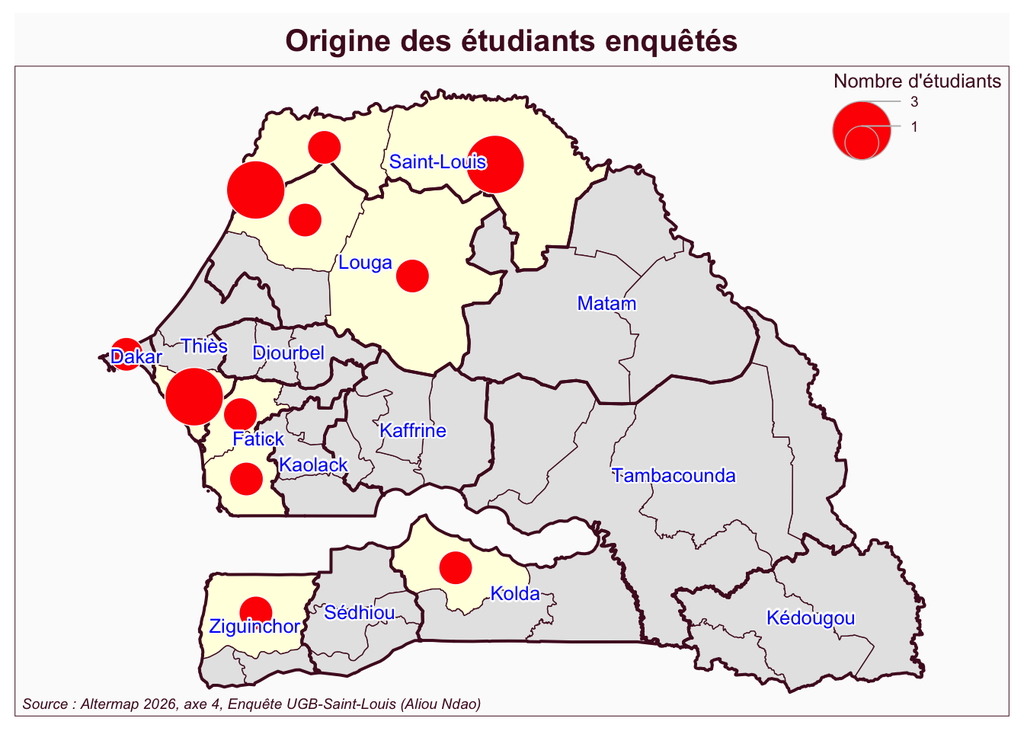

- **Commentaire** :

## A.5 Mobilité interne et trajectoires

### Changement de communes

Réponses à la question des mobilités internes au pays.

```
       n     %
Non    3  14.3
Oui   18  85.7
Total 21 100.0
```

### Trajectoires

On ne traitera pas ici les parcours qui nécessitent un recodage long des réponses. On affiche juste le tableau des trajectoires des étudiants déclarant avoir changé de commune.

Trajectoire des étudiants ayant changé de commune

| id | sex | dep_nais | traj |
| --- | --- | --- | --- |
| L3024 | Une femme | Foundiougne | Kaolack-saint Louis |
| L3024bis | Un homme | NA | Gossas |
| L3029 | Un homme | NA | NA |

- **Commentaire** :

# B. SENTIMENT D’APPARTENANCE TERRITORIALE

## B.1 Echelle d’appartenance

### Echelles citées

On peut tout d’abord examiner quelles échelles ont été les plus mobilisées par les étudiants sans distinguer l’ordre

```
                   n     %
1. Local          16  25.4
2. Arrdt-Dept     10  15.9
3. Région          8  12.7
4. Pays           14  22.2
5. sous-continent  8  12.7
6. continent       6   9.5
8. Autre           1   1.6
Total             63 100.0
```

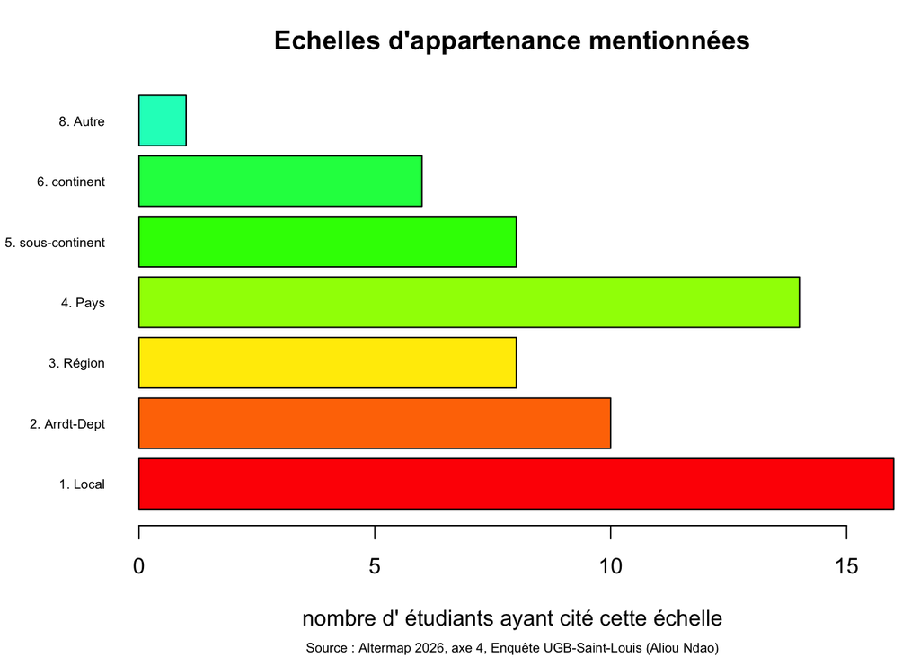

### Echelle citée en premier

On peut ensuite se focaliser sur le premier choix

```
               n     %
1. Local       7  33.3
2. Arrdt-Dept  3  14.3
3. Région      1   4.8
4. Pays        6  28.6
6. continent   4  19.0
Total         21 100.0
```

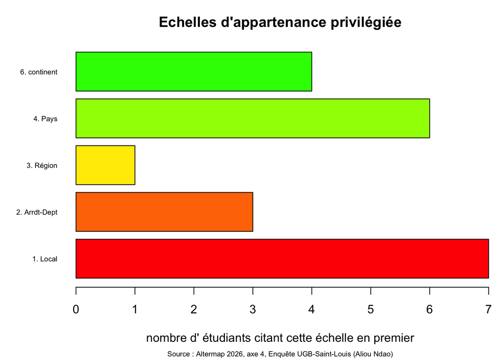

- **Commentaire** :

### Autres échelles

Inventaire des réponses “autres” :

```
           Canada           Kebemer Maison paternelle       Saint-Louis
                1                 1                 1                 1
```

## B.2 Sentiment d’appartenance à des régions non officielles

Cette question interrogeait les étudiants sur leur sentiment d’apprtenance à des espaces non officiels.

### Nombre de réponses

Plusieurs étudiants ont déclaré des appartenances à plusieurs régions.

```
       n   %
1     14  70
2      3  15
3      2  10
4      1   5
Total 20 100
```

### Réponses les plus fréquentes

On évalue les régions les plus fréquemment citées.

| region | n | pct |
| --- | --- | --- |
| Autre | 8 | 26.7 |
| Baol | 7 | 23.3 |
| Sine Saloum | 4 | 13.3 |
| Casamance | 4 | 13.3 |
| Boundou | 3 | 10.0 |
| Cayor | 2 | 6.7 |
| Gabu | 2 | 6.7 |

### Autres réponses

On détaille les réponses “*Autre*” qui ont été proposées par certains étudiants :

```
     Fouta Fouta-Toro    Gandiol       Walo
         2          1          3          1
```

- **Commentaire** :

## B.3 Régions attractives et répulsives

Une manière simple mais efficace de mettre à jour les représentations du Sénégal des étudiants a consisté à leur demander de citer trois régions pays où ils souhaiteraient vivre ou ne pas vivre dans un futur proche. Cela suppose une petite transformation des données pour créer un tableau ou chaque ligne correspond à une réponse sur les pays attractifs ou répulsifs. En d’autres termes les réponses de chaque étudiant correspondront à 6 lignes, 3 pour les régions cités positivement et 3 pour les régions cités négativement.On accompagnera ces réponses des informations que l’on juge utile sur les étudiants afin de pouvoir ensuite faire des regroupements.

A titre d’exemple, voici la forme que prennent les réponses d’un étudiant :

| id | sex | age | dep_nais | ech1 | opi | rnk | NAME_1 |
| --- | --- | --- | --- | --- | --- | --- | --- |
| L3006 | Une femme | 22 | Mbour | 4. Pays | neg | 1 | Dakar |
| L3006 | Une femme | 22 | Mbour | 4. Pays | neg | 2 | Tambacounda |
| L3006 | Une femme | 22 | Mbour | 4. Pays | neg | 3 | Matam |
| L3006 | Une femme | 22 | Mbour | 4. Pays | pos | 1 | Ziguinchor |
| L3006 | Une femme | 22 | Mbour | 4. Pays | pos | 2 | Thiès |
| L3006 | Une femme | 22 | Mbour | 4. Pays | pos | 3 | Saint-Louis |

-**Commentaire :** L’étudiante L3006 est une femme de 22 ans, née dans le département de Mbour et qui déclare en premier le niveau national d’appartenance. Elle déclare qu’elle ne souhaiterait pas vivre dans les régions de Dakar, Tambacounda et Matam. Mais elle aimerait vivre dans les régions de Ziguinchor, Thiès ou Saint-Louis.

### Régions attractives

Si on ne tient pas compte du rang des régions cités positivement, on peut établir un tableau de fréquence indiquant le nombre de fois ou une région a été cité positivement par l’un des étudiants de notre échantillon.

Régions les plus attractives pour les étudiants

| Rang | Nom | Nb. réponses | % étudiants |
| --- | --- | --- | --- |
| 1 | Saint-Louis | 18 | 85.7 |
| 2 | Thiès | 11 | 52.4 |
| 3 | Ziguinchor | 10 | 47.6 |
| 4 | Dakar | 9 | 42.9 |
| 5 | Louga | 5 | 23.8 |
| 7 | Diourbel | 2 | 9.5 |
| 7 | Kolda | 2 | 9.5 |
| 7 | Matam | 2 | 9.5 |
| 10 | Fatick | 1 | 4.8 |
| 10 | Kaolack | 1 | 4.8 |
| 10 | Sédhiou | 1 | 4.8 |
| 10 | Tambacounda | 1 | 4.8 |

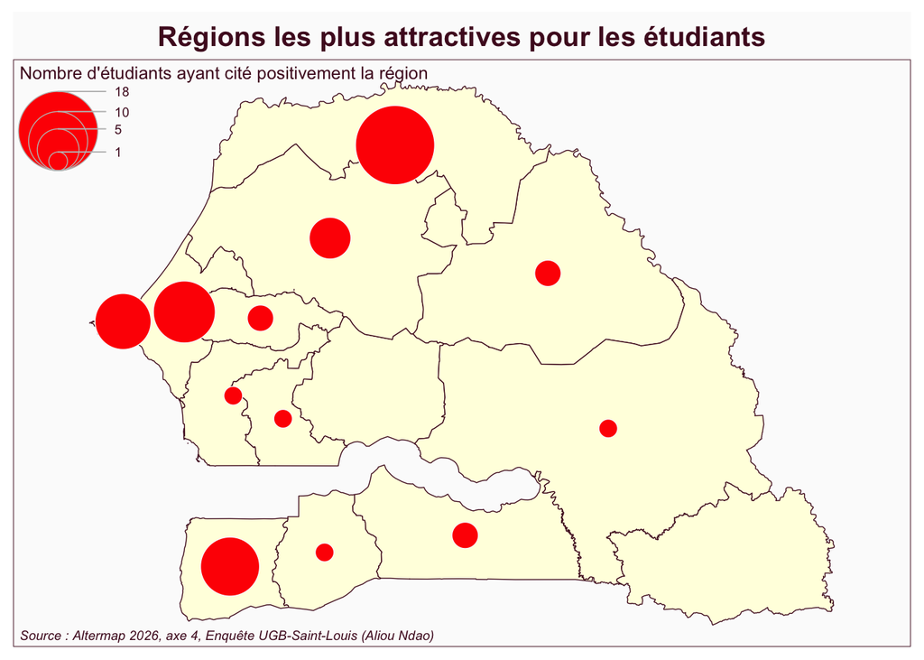

- **Commentaire** :

### Régions répulsives

Régions les plus répulsives pour les étudiants

| Rang | Nom | Nb. réponses | % étudiants |
| --- | --- | --- | --- |
| 1 | Tambacounda | 12 | 57.1 |
| 2 | Matam | 8 | 38.1 |
| 4 | Dakar | 7 | 33.3 |
| 4 | Fatick | 7 | 33.3 |
| 6 | Kédougou | 6 | 28.6 |
| 6 | Sédhiou | 6 | 28.6 |
| 7 | Kolda | 5 | 23.8 |
| 8 | Kaolack | 4 | 19.0 |
| 10 | Kaffrine | 3 | 14.3 |
| 10 | Ziguinchor | 3 | 14.3 |
| 12 | Diourbel | 1 | 4.8 |
| 12 | Louga | 1 | 4.8 |

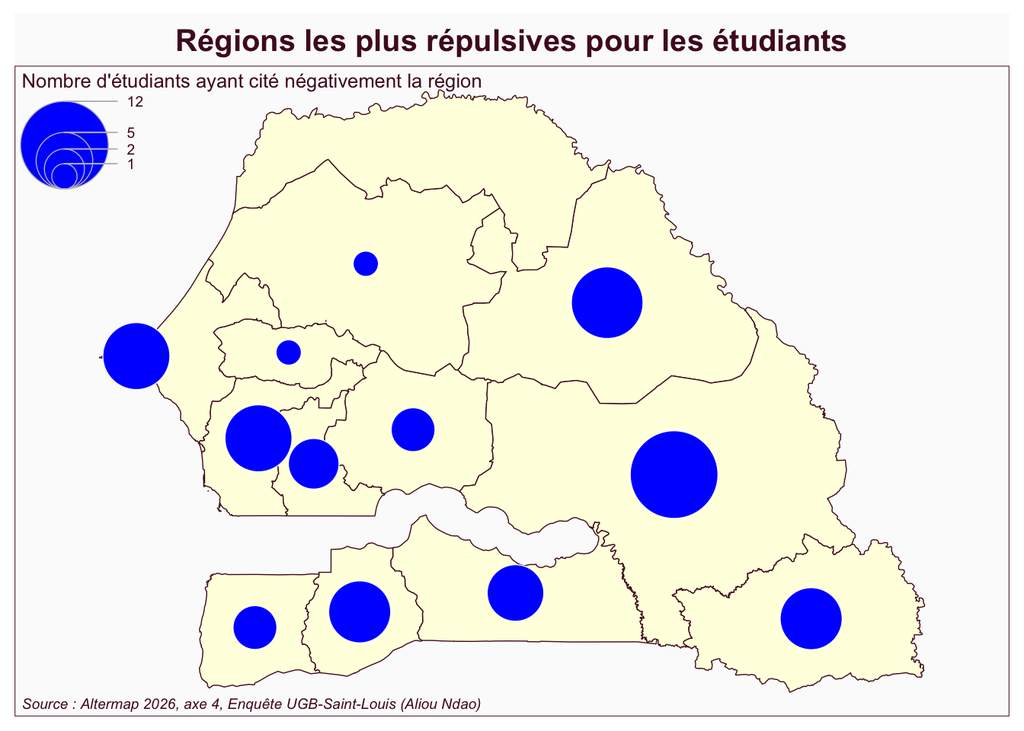

- **Commentaire** :

### Synthèse

L’appréciation que les étudiants donnent d’une région doit être envisagé selon deux dimensions complémentaires, la saillance et l’opinion

- **la saillance** (en anglais *salience*) est le fait qu’une régionse présente à l’esprit dun étudiant lorsqu’on lui demande de porter un jugement. Peu importe que le jugement soit positif ou négatif, si une région est citée par l’étudiant c’est qu’il possède des informations sur elle, qu’il en a reçu et à choisi de les retenir. Bref, la saillance manifeste une reconnaissance de l’existence d’une région et signale sa présence dans la carte mentale de la personne. On la définira donc comme le % des étudiants qui ont cité une région, positivement ou négativement, peu importe, et on la mesurera sur une échelle de 0 (jamais citée) à 100 (toujours citée) :

$Saillance_i = 100\times \frac{Pos_i + Neg_i}{n}$

$Polarisation_i = \frac{Pos_i-Neg_i}{Pos_i+Neg_i}$

### Tableau de synthèse

Saillance et attractivité des régions du Sénégal

| Nom | Négatif | Positif | Total | Saillance (%) | Polarisation |
| --- | --- | --- | --- | --- | --- |
| Saint-Louis | 0 | 18 | 18 | 85.7 | 1.00 |
| Dakar | 7 | 9 | 16 | 76.2 | 0.12 |
| Tambacounda | 12 | 1 | 13 | 61.9 | -0.85 |
| Ziguinchor | 3 | 10 | 13 | 61.9 | 0.54 |
| Thiès | 0 | 11 | 11 | 52.4 | 1.00 |
| Matam | 8 | 2 | 10 | 47.6 | -0.60 |
| Fatick | 7 | 1 | 8 | 38.1 | -0.75 |
| Kolda | 5 | 2 | 7 | 33.3 | -0.43 |
| Sédhiou | 6 | 1 | 7 | 33.3 | -0.71 |
| Kédougou | 6 | 0 | 6 | 28.6 | -1.00 |
| Louga | 1 | 5 | 6 | 28.6 | 0.67 |
| Kaolack | 4 | 1 | 5 | 23.8 | -0.60 |
| Diourbel | 1 | 2 | 3 | 14.3 | 0.33 |
| Kaffrine | 3 | 0 | 3 | 14.3 | -1.00 |

### Graphique de synthèse

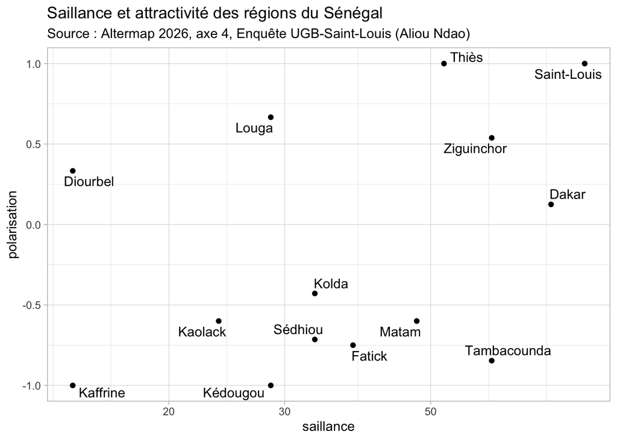

### Cartogramme

On déforme la surface des régions pour leur donner une superficie prportionnelle à leur saillance, c’est-à-dire au nombre de fois où ils ont été cités. Puis on les colorie en fonction de la valeur de l’indice de polarisation , de rouge foncé pour les régions les plus répulsives à bleu foncé pour les plus attractives, en passant par jaune clair pour les régions neutres qui ont autant d’avis positis que négatifs.

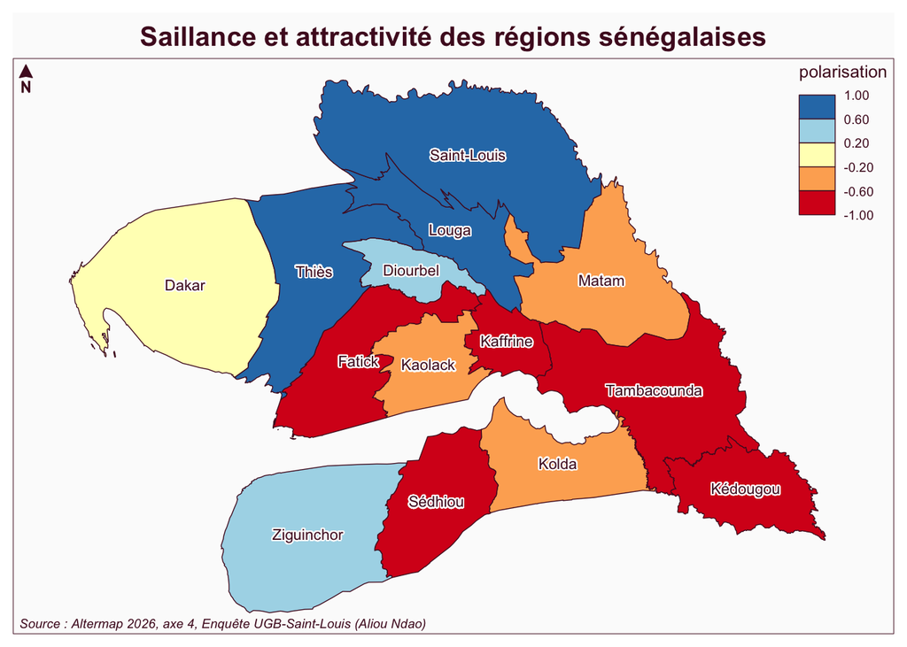

- **Commentaire** :

## B.4 Royaume et entités historiques précoloniales

### Connaissance

```
       n     %
Non    6  28.6
Oui   15  71.4
Total 21 100.0
```

### Nom

```
                                                 n     %
1er capitale de l’Afrique occidentale française  1   6.7
Cayor                                            1   6.7
D’une saloum                                     1   6.7
Djolof                                           1   6.7
Gabu                                             1   6.7
Le royaume du Fouta-Toro                         1   6.7
Le royaume du Sine                               1   6.7
Le Sine                                          1   6.7
NDiambour , royaume de kayor                     1   6.7
Sine Saloum                                      2  13.3
Tekrour                                          1   6.7
Touldé Dimath                                    1   6.7
Walo                                             1   6.7
WALO                                             1   6.7
Total                                           15 100.0
```

- **Commentaire** :

## B.5 Mots associés aux royaumes

On ne retient que les 20 mots les plus fréquents cités au moins trois fois pour construire les nuages de mots ci-dessous.

N.B. Il faudra procéder à un recodage manuel pour regrouper les variantes d’un même mot.

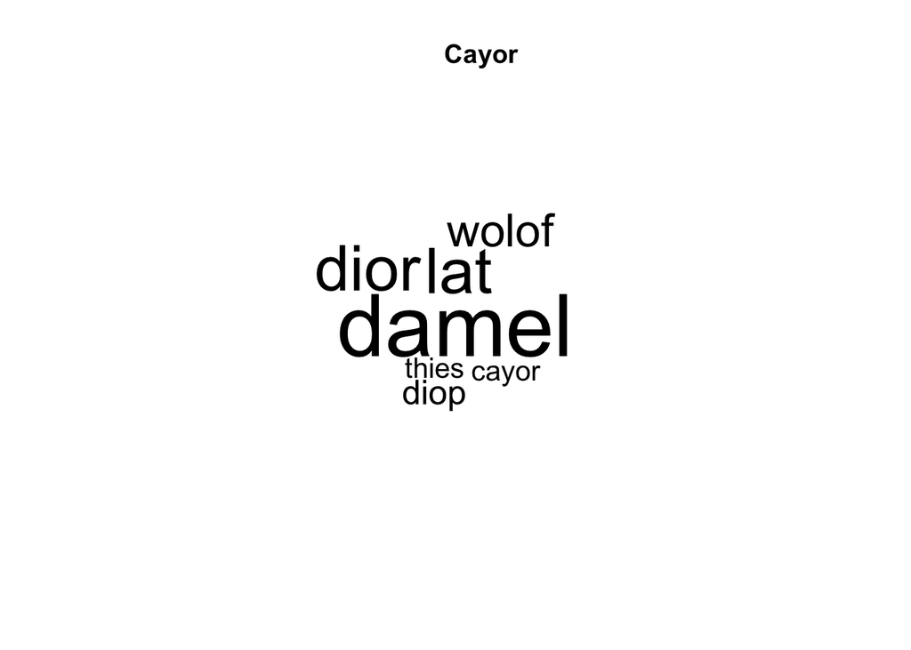

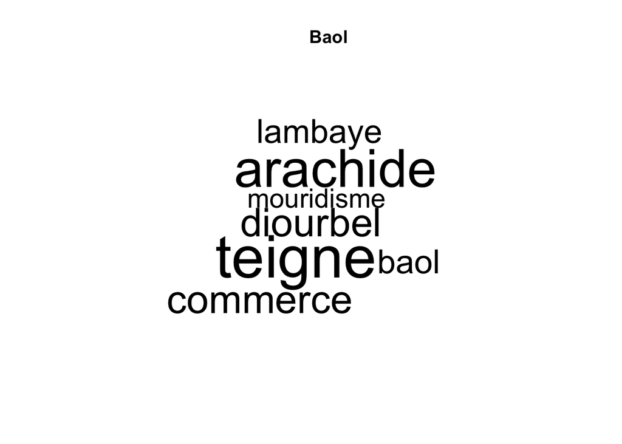

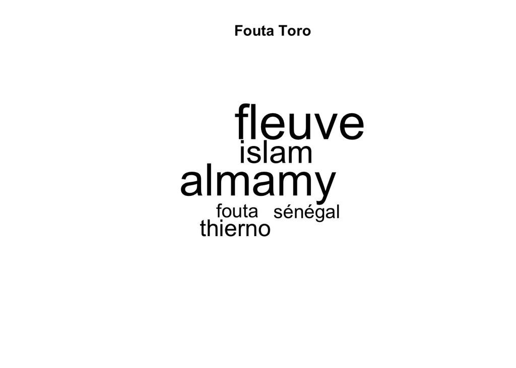

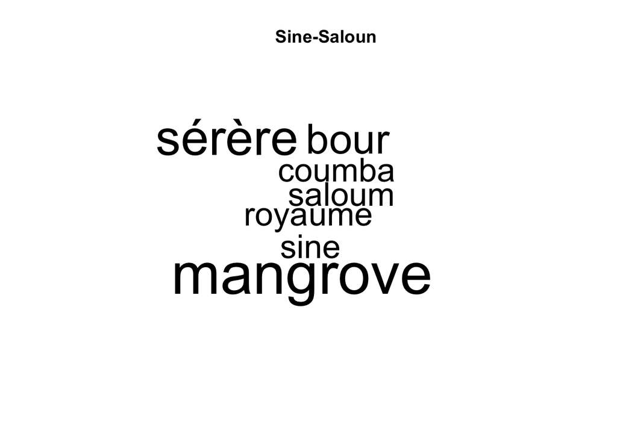

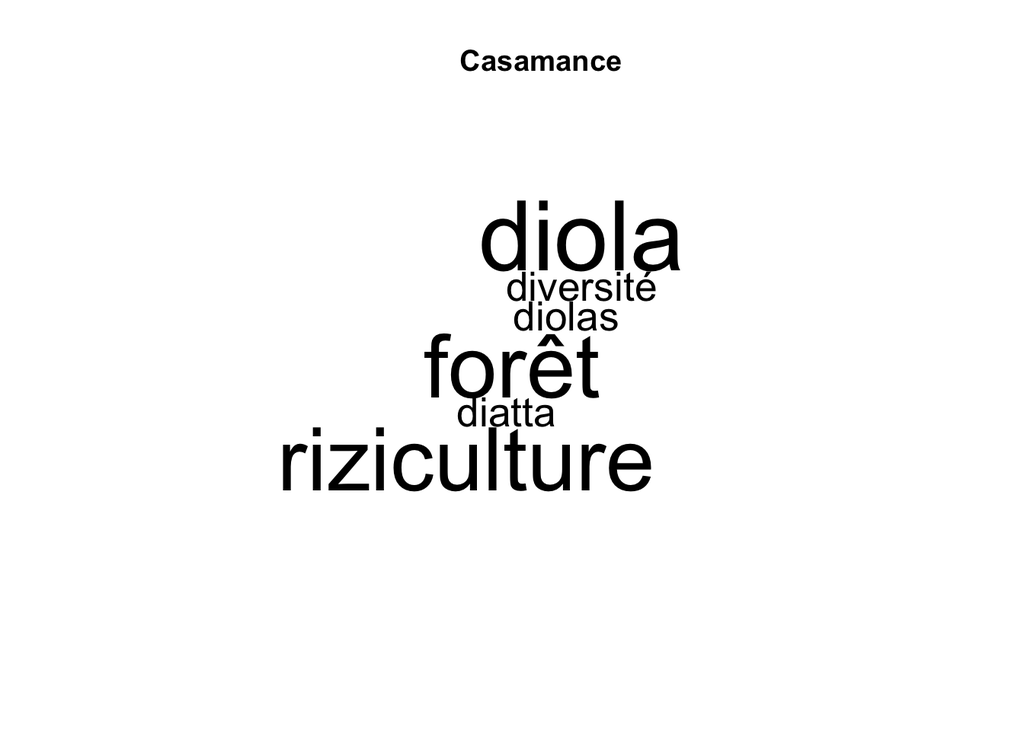

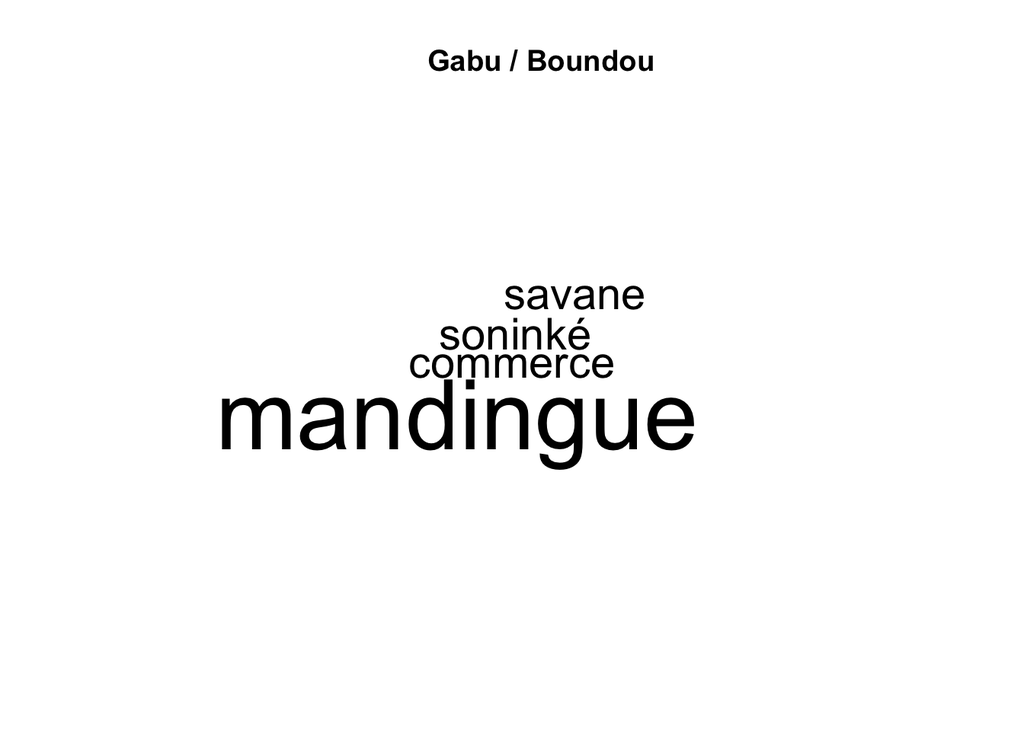

- **Commentaire** :